# hw3

Kevin Neal

April 28, 2015

### Paper questions

#### These errors can all lead to inappropriate conclusions from the data by using datasets that violate the assumptions of models, when better models are available. Can lead to false positives or false negatives in assessing statistical independence.

1. Failing to state number of cases used in correlation; bad because sample size impacts the strength of correlation
2. No 95% CI with correlation coefficient
3. Inappropriate use of a regression line in a scatterplot through an array when only a correlation is involved (i.e. linear regression through cloud of points)
4. Failing to explain/justify inclusion of outliers in a plot and computations; can lead to inappropriate conclusions about correlations of data based on just a few points
5. Use of correlation coefficient when sample size is small or with a non-linear trend
6. Using Pearson on non-Gaussian, heteroscedastic, or non-linear data
7. Not reporting heteroscedasticity of data
8. Inflating importance of a significant outcome based on correlation alone
9. Failure to report number of data points
10. Using regression and correlation interchangeably
11. Justifiably using a scatterplot without detailing the correlation coefficient given
12. Failing to state type of regression line (LSR, MA, RMA)
13. Failure to draw hyperbolic confidence interval lines around regression line, given an appropriate regression line
14. Parallel CI lines, or one parallel and one hyperbolic CI line, around a regression line (CI lines are hyperbolic around regression lines, reflecting greater uncertainty at extremes of the sample distribution)
15. Comparing slopes of two undefined regression lines by [visual?] inspection rather than by an analysis of covariance statistic

### VEGF

```r
vegf.raw <- read.csv("VEGF.csv", header=T)
head(vegf.raw)
```

```
##   PID Time.Point VEGF
## 1 100          1  120
## 2 200          1  158
## 3 400          1  114
## 4 500          1  131
## 5 600          1  112
## 6 800          1 1151
```

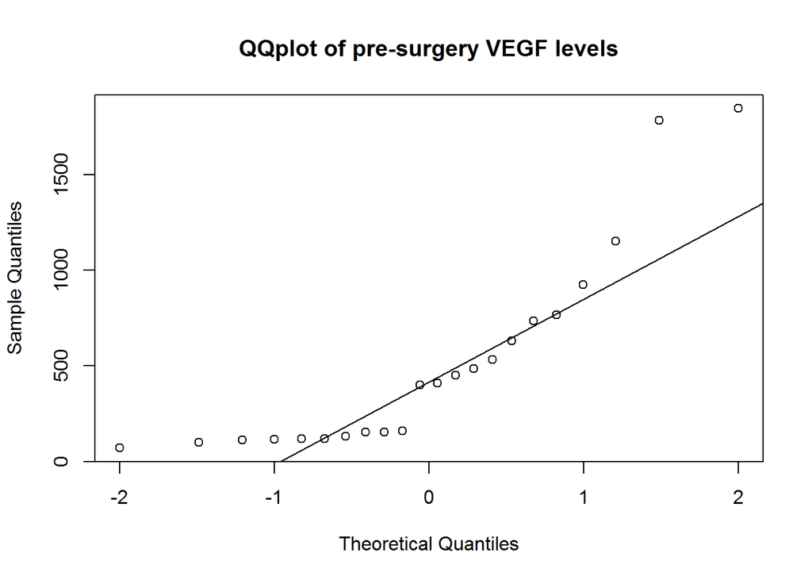

```r
vegf1 <- vegf.raw[vegf.raw$Time.Point==1,]
vegf2 <- vegf.raw[vegf.raw$Time.Point==2,]

qqnorm(vegf1$VEGF, main="QQplot of pre-surgery VEGF levels")
qqline(vegf1$VEGF)
```

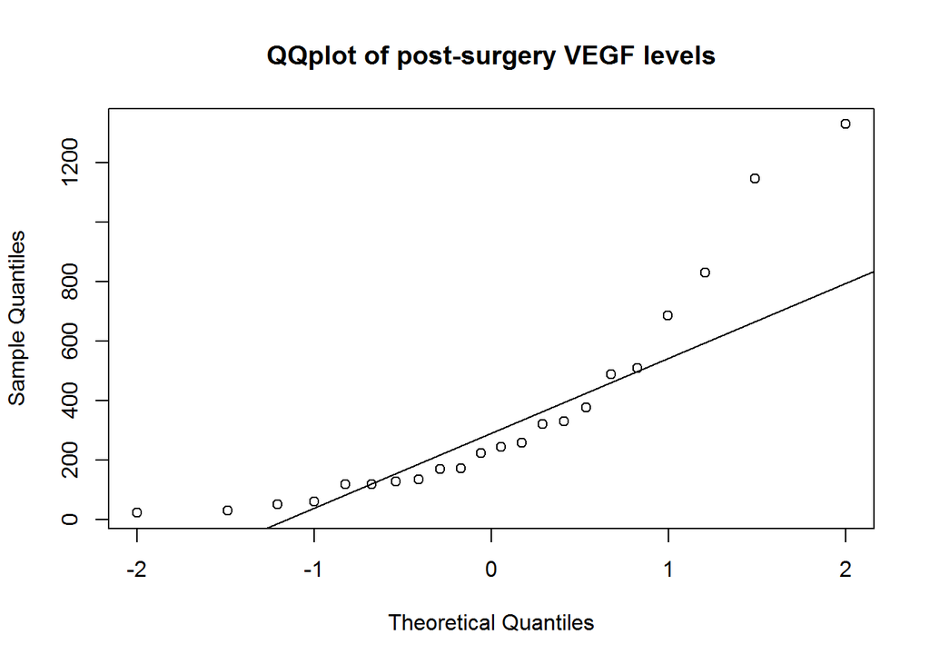

```r
qqnorm(vegf2$VEGF, main="QQplot of post-surgery VEGF levels")
qqline(vegf2$VEGF)
```

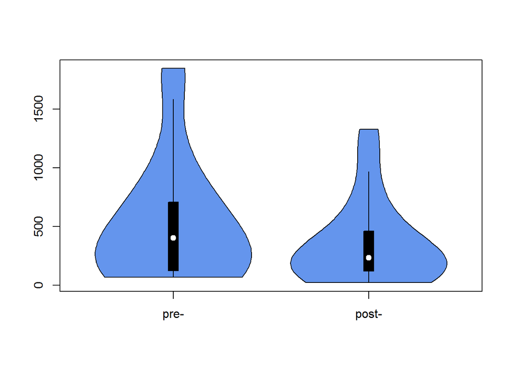

```r
vioplot(vegf1$VEGF, vegf2$VEGF, names=c("pre-","post-"), col=c("cornflowerblue"))
```

```r
# way off from Gaussian; use median and madam!

vegf1boot <- booter(vegf1$VEGF, stat=median) # 404 (136.5, 629)
```

```
## 404 (136.5, 629)
```

```r
vegf1madam <- booter(vegf1boot, stat=madam) # 103 (100.5, 105.5)
```

```
## 105.5 (103, 105.5)
```

```r
vegf2boot <- booter(vegf2$VEGF, stat=median) # 234.5 (131.5, 376)
```

```
## 234.5 (128, 376)
```

```r
vegf2madam <- booter(vegf2boot, stat=madam) # 49 (44.5 49)
```

```
## 49 (44.5, 49)
```

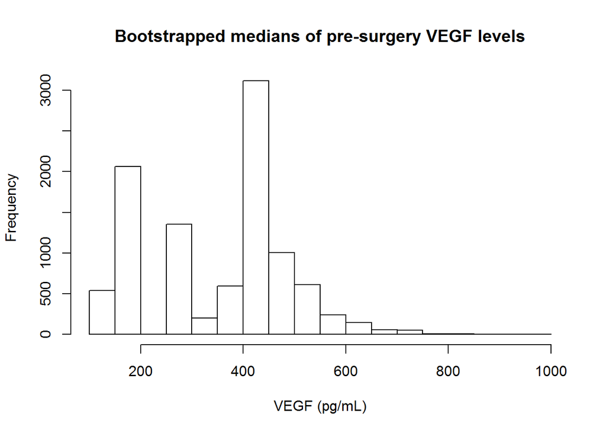

```r
hist(vegf1boot, main="Bootstrapped medians of pre-surgery VEGF levels", xlab="VEGF (pg/mL)")
```

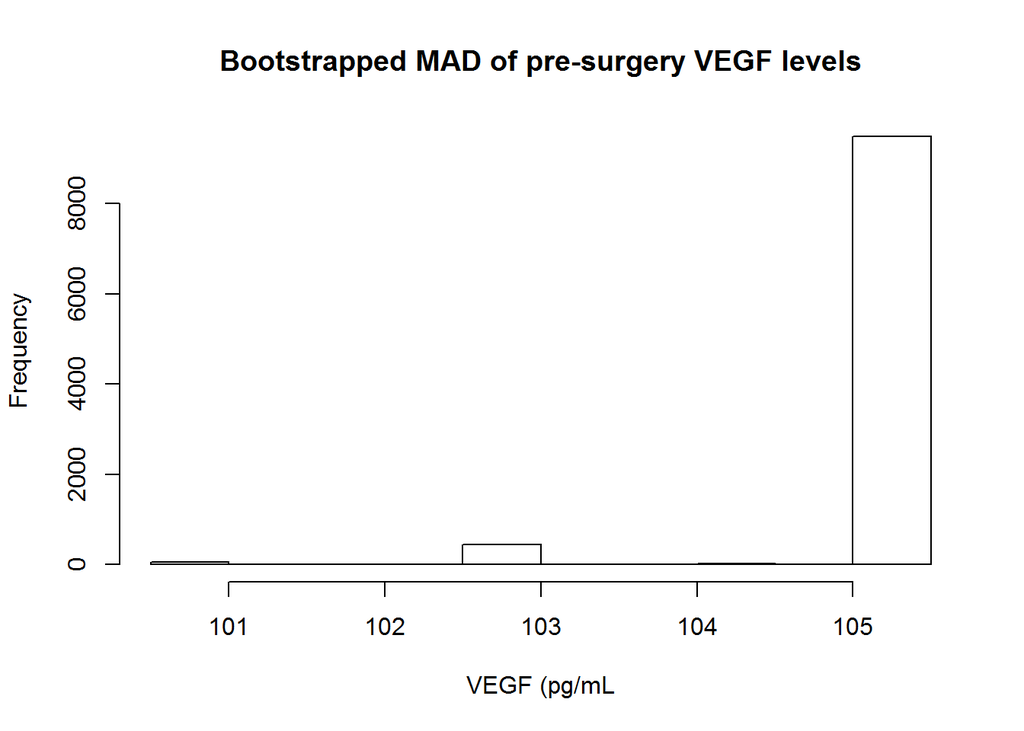

```r
hist(vegf1madam, main="Bootstrapped MAD of pre-surgery VEGF levels", xlab="VEGF (pg/mL")
```

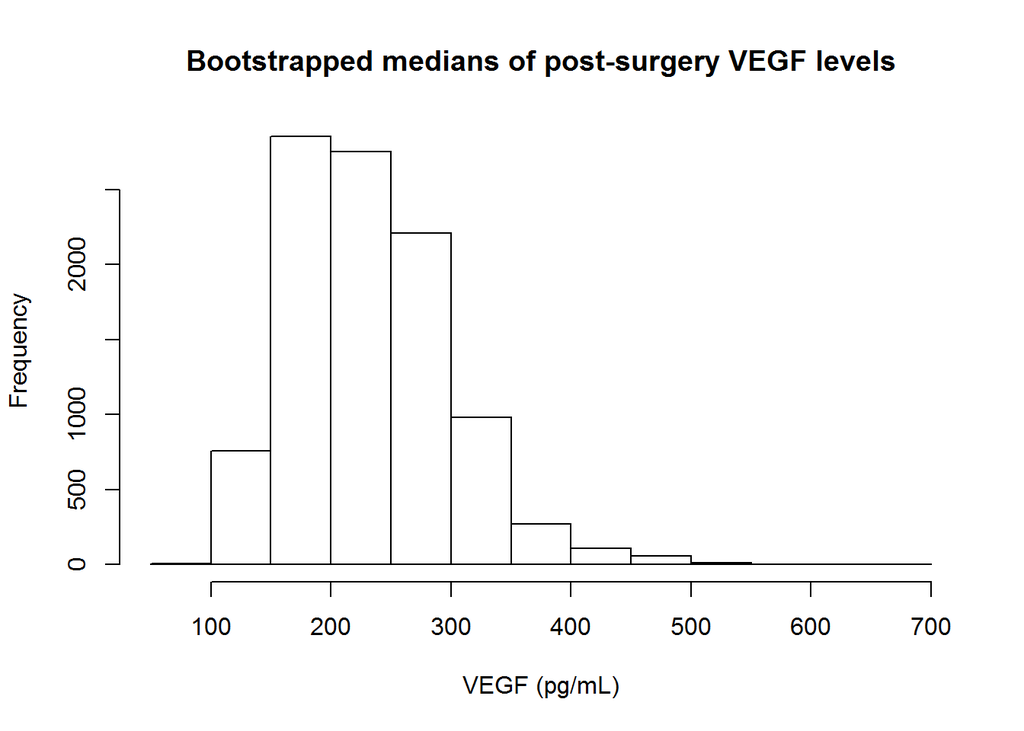

```r
hist(vegf2boot, main="Bootstrapped medians of post-surgery VEGF levels", xlab="VEGF (pg/mL)")
```

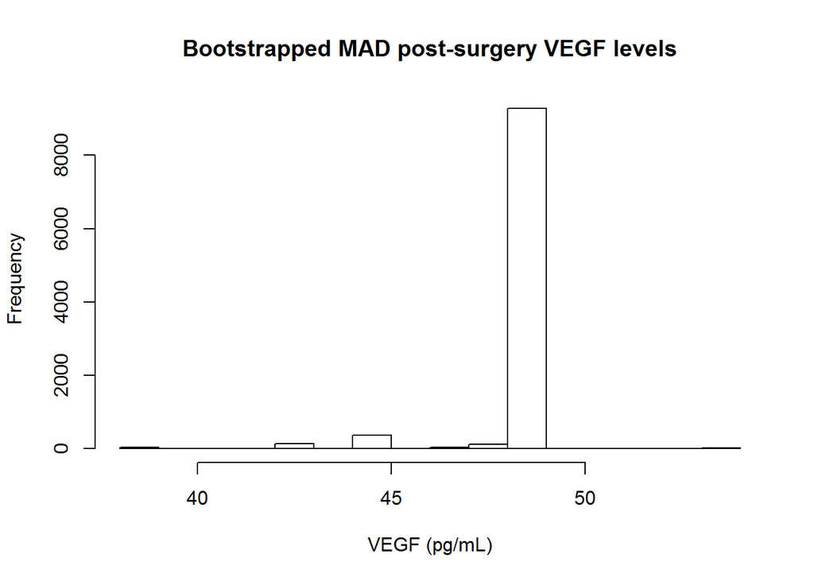

```r
hist(vegf2madam, main="Bootstrapped MAD post-surgery VEGF levels", xlab="VEGF (pg/mL)")
```

### reshape data to do paired comparisons

```r
# test <- spread(vegf.raw, Time.Point, VEGF) # uses tidyr
# test2 <- dcast(vegf.raw, PID ~ Time.Point, value.var="VEGF") # uses reshape2
# both achieve the same outcome

vegf <- spread(vegf.raw, Time.Point, VEGF) # uses tidyr
```

## Bootstrapping pairwise data to get effect size with CI

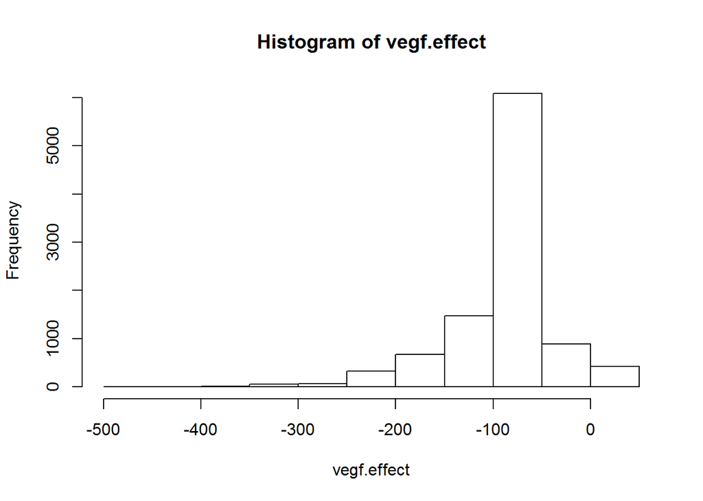

```r
bootind <- function(datasetA, datasetB, reps=10000) {
  indices = c(1:length(datasetA))
  mediandifference = rep(NA,reps)
  for (i in 1:reps) {
    bootindices = sample(indices,length(indices),replace=TRUE)
    bootA = datasetA[bootindices]
    bootB = datasetB[bootindices]
    bootdiff = bootB - bootA # notice this is B - A
    mediandifference[i] = median(bootdiff)
    }
  invisible(mediandifference)
}
#result of this will be the change from timepoint A to timepoint B; if negative, means there was a decrease in measure from A to B

vegf.effect <- bootind(vegf[,2], vegf[,3])
hist(vegf.effect)
```

```r
# get actual median of differences
vegf.median <- median(vegf[,3] - vegf[,2])
vegf.CI <- sortCI(vegf.effect)
```

Effect size of surgery on VEGF: -86.7065 (-245, 9)  
* 95% CI from bootstrap resampling includes zero; report zero effect

## Null hypothesis significance testing of VEGF levels

```r
bootind.nhst <- function(datasetA, datasetB, reps=10000) {
  medianbootdiff = rep(NA,reps)
  for (i in 1:reps) {
    signs = sample(c(-1,1),length(datasetA), replace=T)
    difference = datasetB - datasetA
    bootdifference = signs * difference
    medianbootdiff[i]= median(bootdifference)
  }
  invisible(medianbootdiff)
}
vegf.median
```

```
## [1] -86.7065
```

```r
vegf.nhst <- bootind.nhst(vegf[,2], vegf[,3])
sortCI(vegf.nhst)
```

```
## [1] -74.31  74.31
```

```r
sort(vegf.nhst)[500] # critical d value with one-sided test = -67.95; observed median difference is -86.7
```

```
## [1] -67.95
```

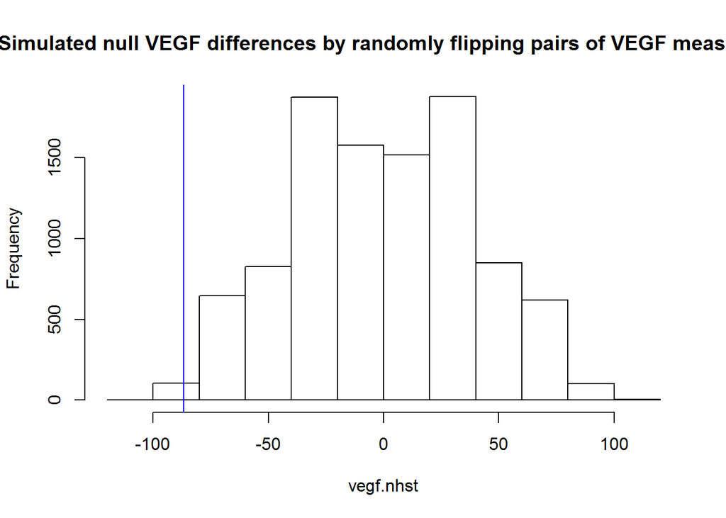

```r
hist(vegf.nhst, main="Simulated null VEGF differences by randomly flipping pairs of VEGF measures")
abline(v=vegf.median, col="blue")
```

```r
pval.low1t <- function(nhst, observed, reps=10000){
  pval <- length(nhst[nhst < observed])/reps
  return(pval)
}

vegf.pval <- pval.low1t(vegf.nhst, -86.7)
# observed median is more extreme than the one-sided test interval here, but already reported zero effect size... does it make sense to do NHST if get zero effect size in the first place???
```

NHST: Observed median is more extreme than the one-sided test interval here, with p = 0.0066

# Statistical Independence

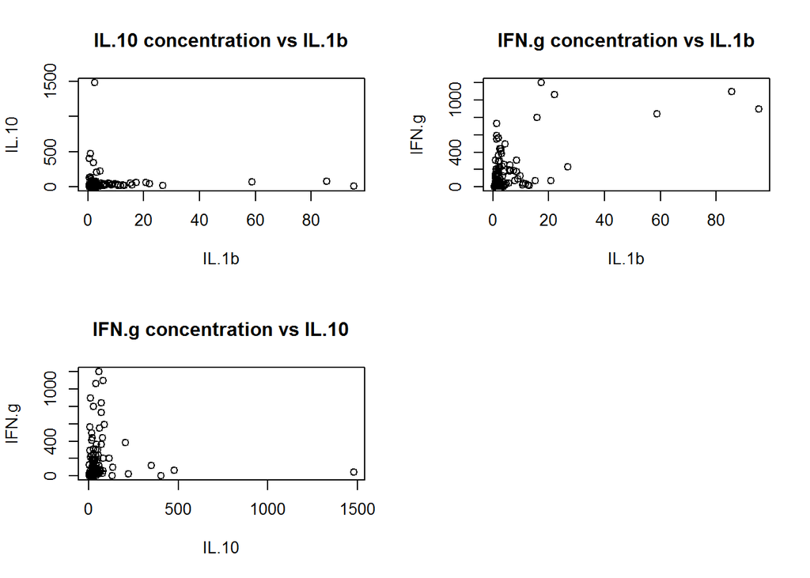

```r
# Do not use Pearson correlation if non-linear; x and y are not both Gaussian; x or y is heteroscedastic (non-uniform variances)

cyto.raw <- read.csv('Cytokine.csv', header = T, na.strings = c('n','0','bad','?','NA','---','-', ' ')) # imports csv with NA's properly interpreted
cyto <- cyto.raw[complete.cases(cyto.raw),] # subsets rows with complete data, i.e. no NA values. Here it removes one row.
attach(cyto)


#IL.1b <- cyto$IL.1b
#IL.10 <- cyto$IL.10
#IFN.g <- cyto$IFN.g
par(mfrow=c(2,2))
plot(IL.1b, IL.10, main="IL.10 concentration vs IL.1b")
plot(IL.1b, IFN.g, main="IFN.g concentration vs IL.1b")
plot(IL.10, IFN.g, main="IFN.g concentration vs IL.10")
par(mfrow=c(1,1))
```

Clearly not linear, Gaussian, or homoscedastic… will use Spearman instead of Pearson

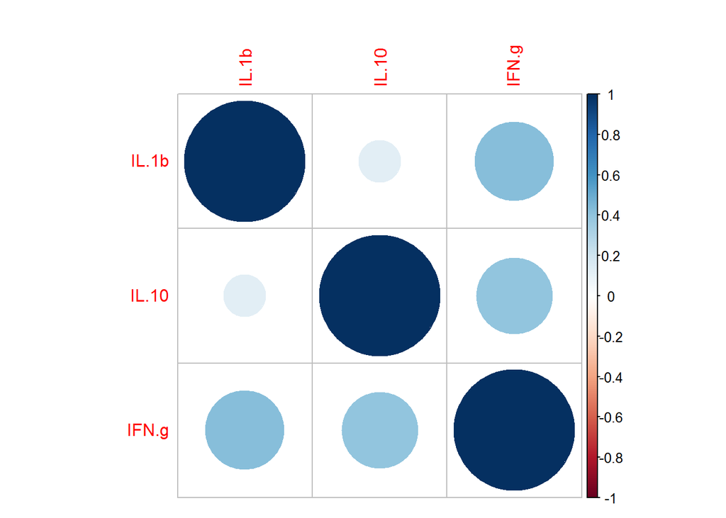

```r
# for Spearman, can use rank() on x and y variables and then do cor(), or just put method="Spearman" in cor()
# cor(cyto$IL.1b, cyto$IL.10, method="spearman")
# can put whole dataframe in cor() and get matrix of Spearman correlation values

booter2 <- function(dataA, dataB=NULL, reps=10000, stat=NULL, ...) {
  bootstat <- rep(NA, reps)
  if (!is.null(dataB)) {
    indices <- c(1:length(dataA))
    for (i in 1:reps) {
      bootindices <- sample(indices, length(indices), replace=T)
      bootstat[i] <- stat(dataA[bootindices], dataB[bootindices])
    }
  } else {
    for (i in 1:reps) {
      bootdata <- sample(dataA, length(dataA), replace=TRUE)
      bootstat[i] <- stat(bootdata)
    }
  }
  invisible(bootstat)
}



spearman <- function(dataA, dataB) {
  cor(dataA, dataB, method="spearman")
}

il1bIFN.spear <- booter2(IL.1b, dataB=IFN.g, stat=spearman)
il1bil10.spear <- booter2(IL.1b, IL.10, stat=spearman)
il10IFN.spear <- booter2(IL.10, IFN.g, stat=spearman)

#spearman(cyto$IL.1b, cyto$IL.10)

histcorr <- function(dataA, dataB, bootdata, main=NULL, method="spearman") {
  hist(bootdata, main=main, xlab=paste(method, "correlation"), tck=0.02, col="gray")
  abline(v=cor(dataA, dataB, method=method, use="pairwise.complete.obs"), lty=6, lwd=3, col="purple")
  abline(v=sort(bootdata)[275], col="blue", lty=1, lwd=2)
  abline(v=sort(bootdata)[9750], col="red", lty=1, lwd=2)
  box()
}

corrplot(cor(cyto, method="spearman", use="pairwise.complete.obs"))
```

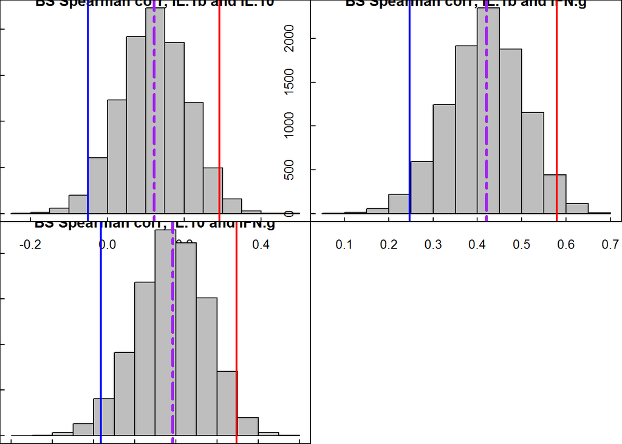

```r
par(mfrow=c(2,2))
histcorr(IL.1b, IL.10, il1bil10.spear, main="BS Spearman corr, IL.1b and IL.10")
histcorr(IL.1b, IFN.g, il1bIFN.spear, main="BS Spearman corr, IL.1b and IFN.g")
histcorr(IL.10, IFN.g, il10IFN.spear, main="BS Spearman corr, IL.10 and IFN.g")

par(mfrow=c(1,1))
```

## 3. NHST

```r
# sample without replacement; shuffle pairs for A and B
bootcor.nh <- function(dataA, dataB=NULL, reps=10000, stat=NULL, ...) {
  bootstat <- rep(NA, reps)
  if (!is.null(dataB)) {
    indices <- c(1:length(dataA))
    for (i in 1:reps) {
      bootindices <- sample(indices, length(indices), replace=F)
      bootstat[i] <- stat(dataA[bootindices], dataB)
    }
  } else {
    for (i in 1:reps) {
      bootdata <- sample(dataA, length(dataA), replace=TRUE)
      bootstat[i] <- stat(bootdata)
    }
  }
  cat("pvalue (upper tail):", length(bootstat[bootstat>cor(dataA, dataB, method="spearman")])/reps)
  invisible(bootstat)
}

cor1.nh <- bootcor.nh(IL.1b, IL.10, stat=spearman) # p = 0.0952
```

```
## pvalue (upper tail): 0.0877
```

```r
cor2.nh <- bootcor.nh(IL.1b, IFN.g, stat=spearman) # p < 0.0001
```

```
## pvalue (upper tail): 0
```

```r
cor3.nh <- bootcor.nh(IL.10, IFN.g, stat=spearman) # p < 0.0001
```

```
## pvalue (upper tail): 0
```

Two correlations are significantly different from zero: IL.1b to IFN.g, and IL.10 to IFN.g.

## 6. Maximal Information Criterion

```r
mine(cyto)$MIC
```

```
##           IL.1b     IL.10     IFN.g
## IL.1b 1.0000000 0.2288959 0.3589710
## IL.10 0.2288959 1.0000000 0.3296205
## IFN.g 0.3589710 0.3296205 0.9999348
```

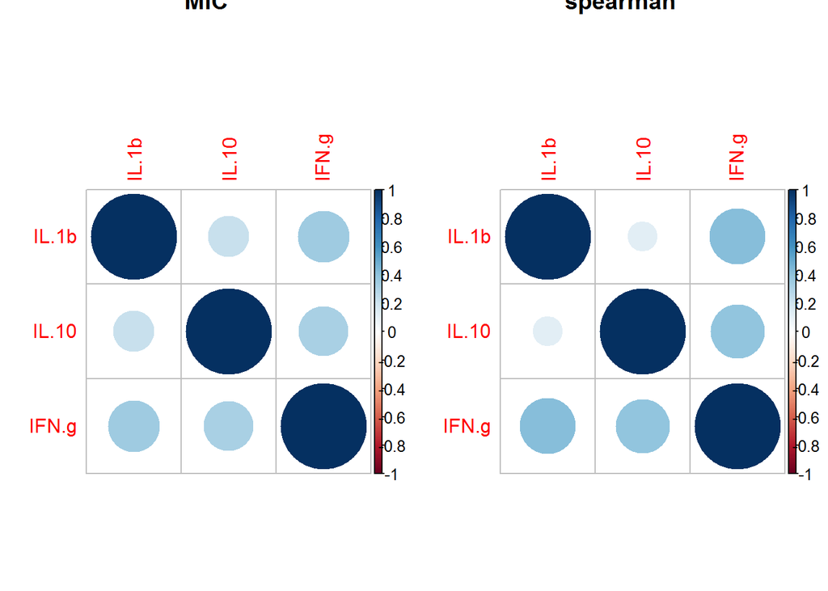

```r
micpval <- read.csv("n=120,alpha=0.6.csv", header=F, na.strings = c('n','0','bad','?','NA','---','-', ' ')) # downloaded p-values for n=120
#micpval2 <- micpval[14:nrow(micpval),1:2] # look for largest number less than your score from mine()$MIC; pvalue is in middle column
# this doesn't seem to want to work... still reads as factors? Just going to look in the file manually
#micpval2 <- micpval[complete.cases(micpval),]
#micpval[micpval==0.35897,] # tedious... how to best call maximum value less than MIC and return the p-value in its row??
#head(micpval2, n=20L)
par(mfrow=c(1,2))
corrplot(mine(cyto)$MIC, main="MIC")
corrplot(cor(cyto, method="spearman", use="pairwise.complete.obs"), main="spearman")
```

```r
par(mfrow=c(1,1))
# MIC:
# IL.1b/IL.10 = 0.2288959; p > 0.05
# IL.1b/IFN.g = 0.3589710; p < 0.000898
# IL.10/IFN.g = 0.3296205; p < 0.00518
```

MIC:  
* IL.1b/IL.10 = 0.2288959; p > 0.05 * IL.1b/IFN.g = 0.3589710; p < 0.000898 * IL.10/IFN.g = 0.3296205; p < 0.00518

MIC results are in agreement with NHST in terms of which correlations are significant and which aren’t. The IL.10/IFN.g correlation is still significant using MIC, but its p-value is larger (0.005 vs 0.0001 with NHST).